# Modeling with ethnobotanyR

Cory Whitney

[figure not shown]

Please remember to cite the `ethnobotanyR` package if you use it in your publications. Use `citation("ethnobotanyR")` to get a citation for the latest version.

```
  Whitney C (2022). _ethnobotanyR: Calculate Quantitative Ethnobotany
  Indices_. doi:10.32614/CRAN.package.ethnobotanyR
  <https://doi.org/10.32614/CRAN.package.ethnobotanyR>, R package
  version 0.1.9, <https://CRAN.R-project.org/package=ethnobotanyR>.

A BibTeX entry for LaTeX users is

  @Manual{,
    title = {ethnobotanyR: Calculate Quantitative Ethnobotany Indices},
    author = {Cory Whitney},
    year = {2022},
    note = {R package version 0.1.9},
    url = {https://CRAN.R-project.org/package=ethnobotanyR},
    doi = {10.32614/CRAN.package.ethnobotanyR},
  }
```

Here we will use an example data set called `ethnobotanydata`, which is provided to show how standard ethnobotany data should be formatted to interface with the `ethnobotanyR` package (Whitney 2022). This is an ethnobotany data set including one column of 20 knowledge holder identifiers `informant` and one of 4 species names `sp_name`. The rest of the columns are the identified ethnobotany use categories. The data in the use categories is populated with counts of uses per person (should be 0 or 1 values).[^1]

Many of the functions in `ethnobotanyR` make use of `select()` and `filter_all()` functions of the `dplyr` package (Wickham, François, et al. 2026) and pipe functions `%>%` from the `magrittr` package (Bache and Wickham 2025). These are easy to use and understand and allow users the chance to pull the code for these functions and change anything they see fit.

First six rows of the example ethnobotany data included with ethnobotanyR

| informant | sp_name | Use_1 | Use_2 | Use_3 | Use_4 | Use_5 | Use_6 | Use_7 | Use_8 | Use_9 | Use_10 |
| --- | --- | --- | --- | --- | --- | --- | --- | --- | --- | --- | --- |
| inform_a | sp_a | 0 | 0 | 1 | 0 | 0 | 0 | 0 | 1 | 1 | 0 |
| inform_a | sp_b | 0 | 0 | 0 | 0 | 0 | 0 | 0 | 0 | 0 | 0 |
| inform_a | sp_c | 0 | 0 | 0 | 0 | 0 | 1 | 1 | 0 | 0 | 0 |
| inform_a | sp_d | 0 | 0 | 0 | 0 | 0 | 0 | 0 | 0 | 0 | 0 |
| inform_b | sp_a | 0 | 1 | 1 | 0 | 0 | 1 | 0 | 0 | 1 | 0 |
| inform_b | sp_b | 1 | 0 | 0 | 0 | 0 | 0 | 1 | 0 | 0 | 0 |

## `ethnobotanyR` modeling functions

Applying quantitative approaches in ethnobotany requires a number of preliminary steps as a foundation for the research. **1.** We should be clear about the aims and objectives of our work. **2.** We should have a sound footing in the theoretical background and body of existing literature on our topic of interest.

Assuming that all this is in place we can start to model systems of interest. Here we will dig in to some holistic assessments and analyses that can be performed in ethnobotany.

The `ethnobotanyR` package provides tools to move beyond descriptive statistics and model the underlying cultural and ecological systems. This vignette demonstrates two complementary approaches:

- The Non-Parametric Bayesian Bootstrap `ethno_boot`: This method helps us understand the uncertainty around our estimates (e.g., the probability of a use). It answers the question: “If we repeated this study many times in this population, what range of results might we get?”
- The Bayesian Cultural Consensus Model `ethno_bayes_consensus`: This method helps us account for varying informant expertise and estimate the “culturally correct” answer for whether a plant has a use. It answers the question: “Given that some informants are more knowledgeable than others, what does the culture truly hold to be a use for this plant?”

### The non-parametric Bayesian bootstrap

When we collect ethnobotany data, we’re usually working with a sample of people from a larger community. The Bayesian bootstrap helps us answer: “How much might our results change if we had interviewed different people?”

Think of it like this: If you randomly re-interviewed people from the same community many times, you’d get slightly different answers each time. The bootstrap simulates this process to show us the range of plausible results.[^2]

```r
sp_a_data <- ethnobotanydata %>% filter(sp_name == "sp_a")

sp_a_use <- ethno_boot(sp_a_data$Use_3, statistic = mean, n1 = 1000)
```

The `ethno_boot` function takes our actual data about species `sp_a` and `Use_3` it simulates re-sampling from the community 1000 times (n1 = 1000). For each simulation `ethno_boot` calculates the average use (`statistic = mean`). It then gives us 1,000 (`n1 = 1000`) plausible average use values

The `ethno_boot` function runs a non-parametric Bayesian bootstrap, with the ability to estimate a population distribution from a set of observations, i.e. it can help us to estimate the larger population of data from which our smaller sample was derived. The procedure begins by estimating the population distribution from the data set. It then simulates the sampling process that led to the set of observations. Finally, for each sampling, the method calculates a sample statistic of interest (i.e. the mean). To calculate that sample statistic the function runs a large number of iterations, each one generating a new bootstrap replicate, and for each bootstrap replicate we calculate the sample estimate of the statistic.[^3]

Here we are interested in the differences (either ‘0’ no use, or ‘1’ use) between species ‘a’ and species ‘b’ or a particular use category. This could be, for example, the differences the use for a specific disease treatment between one species and another. We are using `Use_3` in our data set as the specific use.

```r
sp_b_data <- ethnobotanydata %>% filter(sp_name == "sp_b")

sp_b_use <- ethno_boot(sp_b_data$Use_3, statistic = mean, n1 = 1000)
```

We can calculate the 90% credible interval to determine the lower bound of 0.28 and upper bound of 0.63 for species ‘a’ and 0.11 and upper bound of 0.44 for species ‘b.’

```r
quantile(sp_a_use, c(0.05, 0.95))
```

```
#>      5%     95%
#> 0.27695 0.63000
```

```r
quantile(sp_b_use, c(0.05, 0.95))
```

```
#>      5%     95%
#> 0.11195 0.43905
```

Running `ethno_boot` returns a posterior distribution of the result, i.e. it gives us an estimation, based on our observations, of what a reasonable distribution of the actual population might look like. Plotting these can give some visual probability estimation of differences between the species or informants according to the various indices.

Create a data frame and use the `melt` function to reshape data for the `ggplot2` plotting functions (Wickham, Chang, et al. 2026).

```r
boot_data <- data.frame(sp_a_use, sp_b_use)

ethno_boot_melt <- reshape2::melt(boot_data)
```

Use the `ggplot2` and `ggridges` libraries to plot the data as smooth histograms (Wickham, Chang, et al. 2026; Wilke 2025).

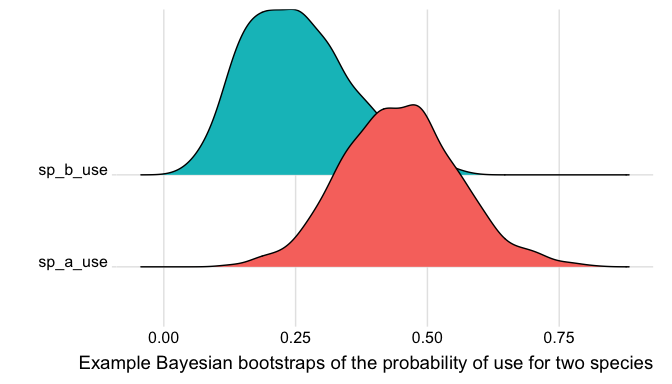

```r
ggplot2::ggplot(ethno_boot_melt, aes(x = value,
                y = variable, fill = variable)) +
                ggridges::geom_density_ridges() +
                ggridges::theme_ridges() +
                theme(legend.position = "none") +
                labs(y= "", x = "Example Bayesian bootstraps of the probability of use for two species")
```

The `ethno_bayes_consensus` function is inspired by the AnthroTools package (see: https://github.com/alastair-JL/AnthroTools). It gives us a measure of the confidence we can have in the reported uses by creating a matrix of probability values. These represent the probability that informant citations for a given use are ‘correct’ (see Oravecz, Vandekerckhove, and Batchelder 2014; Romney, Weller, and Batchelder 1986).

The inputs to the function are informant responses to the use category for each plant, an estimate of informants with the plant, and the number of possible answers. This can be calculated with `URsum` or given as a value.

Depending on the size of the data this function can return a rather large set of probabilities. There are several ways to perform simple visualizations of these probabilities. Here we use the base R function `heatmap` (R Core Team 2025) and the the `dplyr` function `filter` (Wickham, François, et al. 2026) to subset to a single species and create a ridge plot.

```r
ethno_sp_a <- dplyr::filter(ethnobotanydata, sp_name == "sp_a")
```

Generate prior probabilities for all answers as a matrix. If this is not provided the function assumes a uniform distribution `(prior = -1)`. The probability table should have the same number of columns as uses in the provided ethnobotany data and the same number of rows as there are possible answers for the consensus.

First we set the number of possible answers to ‘2.’ This means informants can either agree it is ‘used’ or ‘not used.’

```r
  answers <- 2
```

It is also possible to build the probability table manually using `prop.table` (R Core Team 2025). This can be easier if there are many answers or if there is not always a clear preference about where the higher probability should be for the various answers. This matrix must sum up to 100% chance for either ‘use’ or ‘no use.’

Here we use the `dplyr` function `recode` to reset the informant name factor variable as numeric (Wickham, François, et al. 2026). This way we can set a prior for the informants skill for the `prior_for_answers` input. Assuming that informants have a varying degree of skill that we can assign as a prior for the likelihood that the data we have are correct for `sp_a`.

```r
ethno_compet_sp_a <- dplyr::recode(ethno_sp_a$informant,
    inform_a = 0.9,inform_b = 0.5,inform_c = 0.5,
    inform_d = 0.9, inform_e = 0.9, inform_f = 0.5,
    inform_g = 0.7,inform_h = 0.5,inform_i = 0.9,
    inform_j= 0.9, inform_eight = 0.9,inform_five = 0.6,
    inform_four = 0.5,inform_nine = 0.9,
    inform_one = 0.5, inform_seven = 0.5,
    inform_six= 0.9, inform_ten = 0.9,
    inform_three = 0.9, inform_two = 0.5)
```

Run the `ethno_bayes_consensus` function on the subset data of `sp_a`.

```r
ethno_sp_a_bayes <- ethnobotanyR::ethno_bayes_consensus(ethno_sp_a,
                    answers = 2,
                    #here we keep the default normal distribution with `prior = -1`
                    prior_for_answers = ethno_compet_sp_a)
```

Create a simple heatmap of the results. The `heatmap` function in R (R Core Team 2025) provides a good initial assessment of the results and can be a nice first look at the probability matrix that comes out of the `ethno_bayes_consensus` function. It includes the `hclust` hierarchical cluster analysis using euclidean distance for relationships among both the answers and the uses. This may be useful for looking for similarities among a number of uses or possible answers when there are more than just ‘use’ and ‘non use’ (see below).

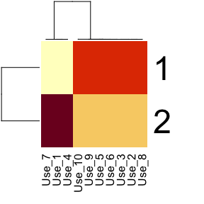

```r
heatmap(ethno_sp_a_bayes)
```

Here the ‘1’ and ‘2’ represent ‘use’ and ‘no use’ (y-axis). The colors are the probabilities (darker is greater). The `hclust` for these is not very informative since there are only 2. However, the `hclust` for the various uses (x-axis) might be helpful in thinking about how the strength of the information about different use categories for `sp_a` are grouped together.

### Richer response data

So far, we’ve modeled data where an informant either confirms (1) or denies (0) a use. However, ethnobotanical data is often richer. An informant might list multiple specific ways a plant is used within a single category (e.g., 5 different food preparations). The `ethno_bayes_consensus` function can model this kind of count data. In this example, we’ll simulate a dataset where informants can report up to 10 distinct uses per category.

Users often have a large number of counts in cells of the data set after categorization (i.e one user cites ten different ‘food’ uses but this is just one category). Let’s say that the theoretical maximum number of use reports in one category, for one species by one informant is 10. It may be useful to work with these richer datasets for the Bayes consensus analysis. The `ggplot2` and `ggridges` libraries can be used to plot the data as smooth histograms. Here we generate some ethnobotany data with up to 10 citations in a single use category for a species by one informant.

```r
set.seed(123) #make random number reproducible
ethno_sp_a_rich <- data.frame(replicate(3,sample(0:10,20,rep=TRUE)))
  names(ethno_sp_a_rich) <-
  gsub(x = names(ethno_sp_a_rich),
  pattern = "X", replacement = "Use_")
  ethno_sp_a_rich$informant <- sample(c('User_1', 'User_2'),
  20, replace=TRUE)
  ethno_sp_a_rich$sp_name <- sample(c('sp_a'),
  20, replace=TRUE)
```

Define the `prior_for_answers` of the data from these new informants in the simulated ethnobotany data. With `User_1` we have high confidence because perhaps we gather this information through ‘walk in the woods’ or another method we feel good about. With `User_2` we assign less confidence. Maybe did our work in a rush or gathered in another way that gives us less confidence.

```r
# Assign prior competencies: higher values (e.g., 0.9) indicate we trust that informant's data more.
ethno_compet_sp_a_rich <-
          dplyr::recode(ethno_sp_a_rich$informant,
          User_1 = 0.9, User_2 = 0.5)
```

We keep a normal prior for the data and the knowledge of the informants.

```r
ethno_sp_a_bayes <- ethnobotanyR::ethno_bayes_consensus(ethno_sp_a_rich,
       answers = 10,
       prior_for_answers = ethno_compet_sp_a_rich,
       prior=-1) #keep a normal prior in this example with -1
```

Create a data frame and melt for the `ggplot2` plotting functions.

```r
ethno_sp_a_bayes_melt <-  ethno_sp_a_bayes %>%
  as.data.frame() %>%
  reshape2::melt()
```

Use the `ggplot2` and `ggridges` libraries to plot the data as smooth histograms.

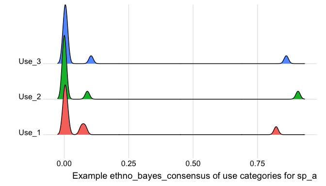

```r
ggplot2::ggplot(ethno_sp_a_bayes_melt, aes(x = value,
                y = variable, fill = variable)) +
                ggridges::geom_density_ridges() +
                ggridges::theme_ridges() +
                theme(legend.position = "none")+
                labs(y= "", x = "Example ethno_bayes_consensus of use categories for sp_a")
```

Visualizing the variation in outcomes can be useful for assessing the amount of confidence we have in the cultural use of the plant across categories.

This vignette has demonstrated how to use ethnobotanyR for two powerful modeling techniques. The Bayesian bootstrap allows you to quantify uncertainty in your estimates, while the cultural consensus model helps you infer shared cultural knowledge from individual responses, accounting for differences in informant competence.

These models provide a robust, quantitative foundation for understanding plant-use systems. For a deeper dive into the theory behind these methods, please see the key references (Oravecz, Vandekerckhove, and Batchelder 2014; Romney, Weller, and Batchelder 1986). To explore more basic descriptive functions in the package, see the ‘Introduction to ethnobotanyR’ vignette.

## References

Bache, Stefan Milton, and Hadley Wickham. 2025. *Magrittr: A Forward-Pipe Operator for r*. https://magrittr.tidyverse.org.

Oravecz, Zita, Joachim Vandekerckhove, and William H. Batchelder. 2014. “Bayesian Cultural Consensus Theory.” *Field Methods* 26 (3): 207–22. https://doi.org/10.1177/1525822X13520280.

R Core Team. 2025. *R: A Language and Environment for Statistical Computing*. Vienna, Austria: R Foundation for Statistical Computing. https://www.R-project.org/.

Romney, A. Kimball, Susan C. Weller, and William H. Batchelder. 1986. “Culture as Consensus: A Theory of Culture and Informant Accuracy.” *American Anthropologist* 88 (2): 313–38. https://www.jstor.org/stable/677564.

Whitney, Cory. 2022. *ethnobotanyR: Calculate Quantitative Ethnobotany Indices*. https://CRAN.R-project.org/package=ethnobotanyR.

Wickham, Hadley, Winston Chang, Lionel Henry, Thomas Lin Pedersen, Kohske Takahashi, Claus Wilke, Kara Woo, Hiroaki Yutani, Dewey Dunnington, and Teun van den Brand. 2026. *Ggplot2: Create Elegant Data Visualisations Using the Grammar of Graphics*. https://ggplot2.tidyverse.org.

Wickham, Hadley, Romain François, Lionel Henry, Kirill Müller, and Davis Vaughan. 2026. *Dplyr: A Grammar of Data Manipulation*. https://dplyr.tidyverse.org.

Wilke, Claus O. 2025. *Ggridges: Ridgeline Plots in Ggplot2*. https://wilkelab.org/ggridges/.

[^1]: The example `ethnobotanydata` is included with the `ethnobotanyR` package but can also be downloaded from GitHub https://github.com/CWWhitney/ethnobotanyR/tree/master/data.
[^2]: Simply put, a bootstrap is any test or metric that uses random sampling with replacement, it is just one of many resampling methods. The common R function `sample()` is one example of a resampling method.
[^3]: Technically, the function uses the Dirichlet distribution as a way to model the randomness of a probability mass function (PMF) with unlimited options for finite sets (e.g. an unlimited amount of dice in a bag). A probability mass function (PMF) is also called a frequency function, it gives probabilities for random variables that are discrete such as UR (there can be only 1 or 0 UR) or for discrete counts like plant uses where there can only be max ‘n’ people interviewed.